# Social media rating analysis

### Analysis of the impact of different social media platforms on the mental health

By Ahmed Sayed

```python
import matplotlib.pyplot as plt
import pandas as pd
import seaborn as sns
```

```python
df=pd.read_csv('social_media_effect.csv')
```

### Exploring the data

```python
df.head()
```

|  | Youtube | Facebook | Twitter | Instagram |
| --- | --- | --- | --- | --- |
| 0 | 7 | 5 | 5 | 4 |
| 1 | 6 | 1 | 4 | 1 |
| 2 | 9 | 8 | 10 | 7 |
| 3 | 7 | 3 | 4 | 1 |
| 4 | 8 | 6 | 1 | 10 |

```python
df.shape
```

```
(64, 4)
```

```python
df.isnull().any()
```

```
Youtube      False
Facebook     False
Twitter      False
Instagram    False
dtype: bool
```

### Encoding quantitave variables into categorical variables

```python
llist=list()
for value in df['Youtube']:
    if value < 3 :
        x='Very Negative'
        llist.append(x)
    elif value >= 3 and value <5:
        x='Negative'
        llist.append(x)
    elif value >=5 and value <7:
        x='Neutral'
        llist.append(x)
    else:
        x='Positive'
        llist.append(x)
df['Youtube_rate']=llist
```

```python
llist2=list()
for value in df['Facebook']:
    if value < 3 :
        x='Very Negative'
        llist2.append(x)
    elif value >= 3 and value <5:
        x='Negative'
        llist2.append(x)
    elif value >=5 and value <7:
        x='Neutral'
        llist2.append(x)
    else:
        x='Positive'
        llist2.append(x)
df['Facebook_rate']=llist2
```

```python
llist3=list()
for value in df['Twitter']:
    if value < 3 :
        x='Very Negative'
        llist3.append(x)
    elif value >= 3 and value <5:
        x='Negative'
        llist3.append(x)
    elif value >=5 and value <7:
        x='Neutral'
        llist3.append(x)
    else:
        x='Positive'
        llist3.append(x)
df['Twitter_rate']=llist3
```

```python
llist4=list()
for value in df['Instagram']:
    if value < 3 :
        x='Very Negative'
        llist4.append(x)
    elif value >= 3 and value <5:
        x='Negative'
        llist4.append(x)
    elif value >=5 and value <7:
        x='Neutral'
        llist4.append(x)
    else:
        x='Positive'
        llist4.append(x)
df['Instagram_rate']=llist4
```

```python
df.head()
```

|  | Youtube | Facebook | Twitter | Instagram | Youtube_rate | Facebook_rate | Twitter_rate | Instagram_rate |
| --- | --- | --- | --- | --- | --- | --- | --- | --- |
| 0 | 7 | 5 | 5 | 4 | Positive | Neutral | Neutral | Negative |
| 1 | 6 | 1 | 4 | 1 | Neutral | Very Negative | Negative | Very Negative |
| 2 | 9 | 8 | 10 | 7 | Positive | Positive | Positive | Positive |
| 3 | 7 | 3 | 4 | 1 | Positive | Negative | Negative | Very Negative |
| 4 | 8 | 6 | 1 | 10 | Positive | Neutral | Very Negative | Positive |

### Exploratory Data analysis

> Note that this data was collected by a survey that asked people to rate these social media platforms:

> Youtube

> Facebook

> Twitter

> Instagram

> The rate is from 0 to 10 where 0 means that this plaform has a negative impact on their mental health and 10 means that it has a postive impact on their mental health

### What is the impact of Youtube on people's mental health ?

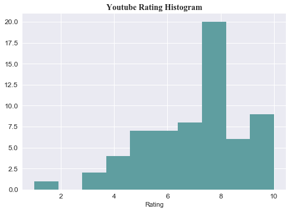

```python
plt.style.use('seaborn')
df['Youtube'].hist(bins=10,color='#5F9EA0')
plt.title('Youtube Rating Histogram',fontname='Times new roman',fontsize=14)
plt.xlabel('Rating')
plt.xticks(fontsize=12)
plt.yticks(fontsize=12)
plt.show()
```

```
Rate: ,
 Positive         0.671875
Neutral          0.218750
Negative         0.093750
Very Negative    0.015625
Name: Youtube_rate, dtype: float64
```

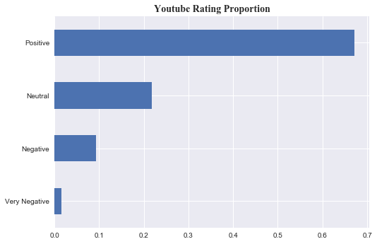

```python
print('Rate: ,\n',df['Youtube_rate'].value_counts(normalize=True))
df['Youtube_rate'].value_counts(normalize=True).sort_values().plot(kind='barh')
plt.title('Youtube Rating Proportion',fontname='Times new roman',fontsize=14)
```

```
column name: ,
 Positive         43
Neutral          14
Negative          6
Very Negative     1
Name: Youtube_rate, dtype: int64
```

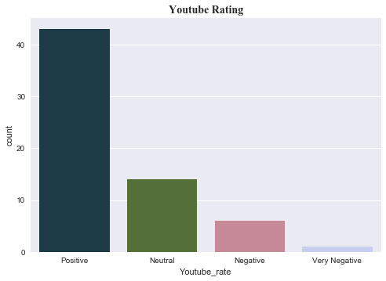

```python
print('column name: ,\n',df['Youtube_rate'].value_counts())
sns.countplot(x='Youtube_rate', data=df,palette="cubehelix")
plt.title('Youtube Rating',fontname='Times new roman',fontsize=14)
```

#### INSIGHT 1: Youtube seems to have a positive impact on menatal health as 67% of the partcipant chose that it has positive impact, 22% percent chose that it is neutral, and about 11% of participant fount it negative or very negative.

- Youtube is likely to be a platform that has a good impact on it's users, maybe because of the free educational material that exist on it, but there is also a negative impact from this platform as it was showed in this survey maybe because of the bad content that also exist on Youtube

### What is the impact of Facebook on people's mental health ?

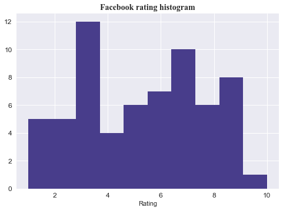

```python
df['Facebook'].hist(bins=10,color='#483D8B')
plt.title('Facebook rating histogram',fontname='Times new roman',fontsize=14)
plt.xlabel('Rating')
plt.xticks(fontsize=12)
plt.yticks(fontsize=12)
plt.show()
```

```
Rate: ,
 Very Negative    0.156250
Neutral          0.203125
Negative         0.250000
Positive         0.390625
Name: Facebook_rate, dtype: float64
```

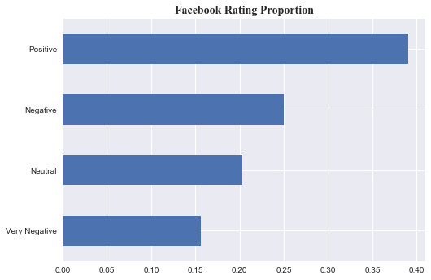

```python
print('Rate: ,\n',df['Facebook_rate'].value_counts(normalize=True).sort_values())
df['Facebook_rate'].value_counts(normalize=True).sort_values().plot(kind='barh')
plt.title('Facebook Rating Proportion',fontname='Times new roman',fontsize=14)
```

[output not shown]

[figure not shown]

```python
print('column name: ,\n',df['Facebook_rate'].value_counts().sort_values())
sns.countplot(x='Facebook_rate', data=df,palette="magma")
plt.title('Facebook Rating',fontname='Times new roman',fontsize=14)
```

#### INSIGHT 2: Facebook seems to have a negative impact on the mental health of it's user, 25% of the participant in the survey said that facebook has negative impact and 15.6% said that it has very negative impact, so we have 40.6% of the people saw that facebook has a negative impact on their mental health and 39% of the people said that it has a positive impact on their mental health, and 20.3% of the partcipant said that facebook doesn't have impact on them

- The answer is not clear whether facebook has a negative or positive impact on the mental health, but we need to ba cautious when using this platform as it has a high probability of impacting our mind negatively.

### What is the impact of Twitter on people's mental health ?

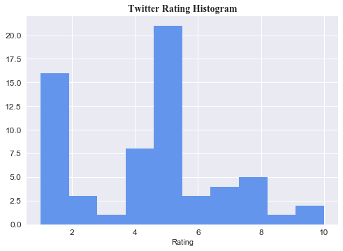

```python
df['Twitter'].hist(bins=10,color='#6495ED')
plt.title('Twitter Rating Histogram',fontname='Times new roman',fontsize=14)
plt.xlabel('Rating')
plt.xticks(fontsize=12)
plt.yticks(fontsize=12)
plt.show()
```

```
Rate: ,
 Negative         0.140625
Positive         0.187500
Very Negative    0.296875
Neutral          0.375000
Name: Twitter_rate, dtype: float64
```

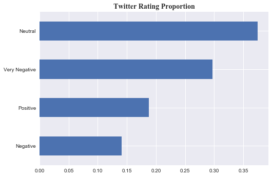

```python
print('Rate: ,\n',df['Twitter_rate'].value_counts(normalize=True).sort_values())
df['Twitter_rate'].value_counts(normalize=True).sort_values().plot(kind='barh')
plt.title('Twitter Rating Proportion',fontname='Times new roman',fontsize=14)
```

[output not shown]

[figure not shown]

```python
print('column name: ,\n',df['Twitter_rate'].value_counts().sort_values())
sns.countplot(x='Twitter_rate', data=df,palette="magma")
plt.title('Twitter Rating',fontname='Times new roman',fontsize=14)
```

#### INSIGHT 3: 37.5% of the participants of the survey found that twitter doesn't have any impact of them, maybe because the target audience of this survey is egyptian youth from age 18 to 25 and they are not twitter users, 29.6% of the participants said that twitter has a very negative impact on their mental health, 14% said that it has a negative impact on them, and 18.75% of the particpants said that twitter has a positive impact on them

- Maybe the answers related to twitter is not representative becuase the target audience( Egyptian youth in age 18-25) are not regular twitter users

### What is the impact of Instagram on people's mental health ?

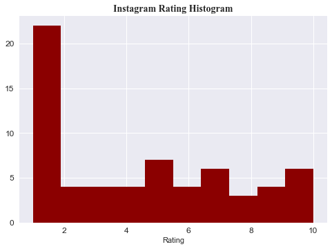

```python
df['Instagram'].hist(bins=10,color='#8B0000')
plt.title('Instagram Rating Histogram',fontname='Times new roman',fontsize=14)
plt.xlabel('Rating')
plt.xticks(fontsize=12)
plt.yticks(fontsize=12)
plt.show()
```

```
Rate: ,
 Negative         0.125000
Neutral          0.171875
Positive         0.296875
Very Negative    0.406250
Name: Instagram_rate, dtype: float64
```

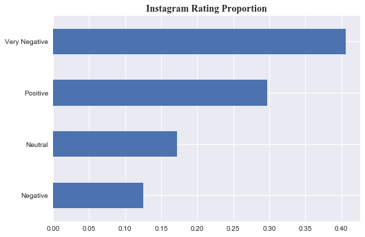

```python
print('Rate: ,\n',df['Instagram_rate'].value_counts(normalize=True).sort_values())
df['Instagram_rate'].value_counts(normalize=True).sort_values().plot(kind='barh')
plt.title('Instagram Rating Proportion',fontname='Times new roman',fontsize=14)
```

[output not shown]

[figure not shown]

```python
print('column name: ,\n',df['Instagram_rate'].value_counts().sort_values())
sns.countplot(x='Instagram_rate', data=df,palette="viridis")
plt.title('Instagram Rating',fontname='Times new roman',fontsize=14)
```

#### INSIGHT 4: Instagram is clearly a platform that has a negative impact on it's users, According to the 40.6% of the partcipants in this survey instagram has a very bad impact on their mental health, 12.5% of the participants said that instagram has a negaive impact on the mental health, 29% of the participants said it has a posive impact on them ,and 17% said it doesn't have impact on them

- The majority of the paricipants in this survey said that instagram is a very negative social media platform, maybe because it doesn't reflect the reality of life.
- Accoring to times website it was also associated with high levels of anxiety, depression, bullying and FOMO, or the “fear of missing out.”
- Source : https://time.com/4793331/instagram-social-media-mental-health/

```python
print('Median Rating: \n',df.loc[:,'Youtube':'Instagram'].median().sort_values())
```

```
Median Rating:
 Instagram    4.0
Twitter      5.0
Facebook     5.5
Youtube      8.0
dtype: float64
```

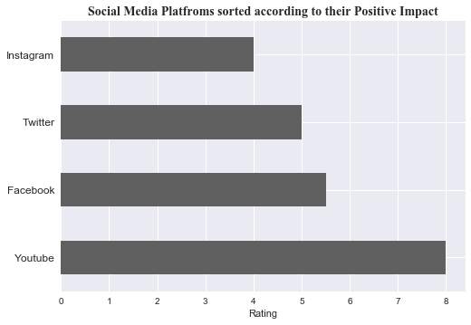

```python
df.loc[:,'Youtube':'Instagram'].median().plot(kind='barh',color='#606060')
plt.title('Social Media Platfroms sorted according to their Positive Impact',fontname='Times new roman',fontsize= 14)
plt.yticks(fontsize=12)
plt.xlabel('Rating')
plt.show()
```

### According to data collected from this survey

- Youtube has the highest positive effect on people's mentaility and Instagram has negative effect on people's mentality,
- Maybe because instagram doesn't reflect the reality and it makes people feel bad about theirselves, and maybe youtube was the best platform in terms of it's effect on mental health as it makes people learn more stuff and increase their value

### Thank you for your time and i would grealy appreciate it if you fill in the survey, in order to make our analysis more robust

https://docs.google.com/forms/d/1YqwimhNlw9bZG30hgcH2iMtR9dB0TC9fU4g6_FTr0IY/edit#question=193574675&field=366340186